# EXAMEN 1 - LABORATORIO Estadística General

Análisis Estadístico Descriptivo - Pizza Delivery Dataset

Victor Daniel Arango Sohm

2025-08-14

# Introducción

Este análisis examina los datos de entrega de pizza de un restaurante italiano durante mayo de 2014, enfocándose en estadística descriptiva y visualización de datos.

# Carga y preparación de datos

```r
# Cargar librerías necesarias
library(ggplot2)
library(dplyr)
library(gridExtra)

# Cargar los datos
datos <- read.csv("pizzadelivery.csv", header = FALSE, stringsAsFactors = FALSE)

# Asignar nombres de columnas
colnames(datos) <- c("id", "day", "date", "time", "operator", "branch",
                     "driver", "temperature", "bill", "pizzas",
                     "free_wine", "got_wine", "discount_customer")

# Convertir variables a tipos apropiados
datos$id <- as.numeric(datos$id)
datos$time <- as.numeric(datos$time)
datos$temperature <- as.numeric(datos$temperature)
datos$bill <- as.numeric(datos$bill)
datos$pizzas <- as.numeric(datos$pizzas)
datos$free_wine <- as.numeric(datos$free_wine)
datos$got_wine <- as.numeric(datos$got_wine)
datos$discount_customer <- as.numeric(datos$discount_customer)

# Convertir variables categóricas a factor
datos$day <- as.factor(datos$day)
datos$operator <- as.factor(datos$operator)
datos$branch <- as.factor(datos$branch)
datos$driver <- as.factor(datos$driver)

# Mostrar estructura de los datos
str(datos)
```

```
## 'data.frame':    1267 obs. of  13 variables:
##  $ id               : num  NA 1 2 3 4 5 6 7 8 9 ...
##  $ day              : Factor w/ 8 levels "day","Friday",..: 1 6 6 6 6 6 6 6 6 6 ...
##  $ date             : chr  "date" "01-May-14" "01-May-14" "01-May-14" ...
##  $ time             : num  NA 35.1 25.2 45.6 29.4 30 40.3 48.7 34 28.2 ...
##  $ operator         : Factor w/ 3 levels "Laura","Melissa",..: 3 1 2 2 2 2 2 1 2 1 ...
##  $ branch           : Factor w/ 4 levels "branch","Centre",..: 1 3 3 4 3 4 2 4 4 2 ...
##  $ driver           : Factor w/ 6 levels "Bruno","Domenico",..: 3 1 6 6 6 6 1 1 5 5 ...
##  $ temperature      : num  NA 68.3 71 53.4 70.3 71.5 60.8 58.3 68.1 64.9 ...
##  $ bill             : num  NA 58.4 26.4 58.1 35.2 38.4 61.8 57.9 35.8 36.6 ...
##  $ pizzas           : num  NA 4 2 3 3 2 4 3 2 2 ...
##  $ free_wine        : num  NA 0 0 1 0 0 1 1 0 0 ...
##  $ got_wine         : num  NA 0 0 0 0 0 1 1 0 0 ...
##  $ discount_customer: num  NA 1 0 0 0 0 0 0 0 0 ...
```

```r
head(datos)
```

```
##   id      day      date time operator branch    driver temperature bill pizzas
## 1 NA      day      date   NA operator branch    driver          NA   NA     NA
## 2  1 Thursday 01-May-14 35.1    Laura   East     Bruno        68.3 58.4      4
## 3  2 Thursday 01-May-14 25.2  Melissa   East Salvatore        71.0 26.4      2
## 4  3 Thursday 01-May-14 45.6  Melissa   West Salvatore        53.4 58.1      3
## 5  4 Thursday 01-May-14 29.4  Melissa   East Salvatore        70.3 35.2      3
## 6  5 Thursday 01-May-14 30.0  Melissa   West Salvatore        71.5 38.4      2
##   free_wine got_wine discount_customer
## 1        NA       NA                NA
## 2         0        0                 1
## 3         0        0                 0
## 4         1        0                 0
## 5         0        0                 0
## 6         0        0                 0
```

# Problema 1: Clasificación de Variables

## Análisis de Variables

```r
# Crear tabla de clasificación de variables
clasificacion <- data.frame(
  Variable = c("id", "day", "date", "time", "operator", "branch", "driver",
               "temperature", "bill", "pizzas", "free_wine", "got_wine", "discount_customer"),
  Tipo = c("Cuantitativa", "Categórica", "Categórica", "Cuantitativa",
           "Categórica", "Categórica", "Categórica", "Cuantitativa",
           "Cuantitativa", "Cuantitativa", "Categórica", "Categórica", "Categórica"),
  Subtipo = c("Discreta", "Nominal", "Ordinal", "Continua",
              "Nominal", "Nominal", "Nominal", "Continua",
              "Continua", "Discreta", "Nominal", "Nominal", "Nominal"),
  Descripción = c("Identificador único", "Día de la semana", "Fecha del pedido",
                  "Tiempo de entrega (min)", "Operador telefónico", "Sucursal del restaurant",
                  "Repartidor", "Temperatura de entrega (°C)", "Cuenta total (euros)",
                  "Número de pizzas", "Vino gratis (0/1)", "Llevó vino (0/1)", "Cliente con descuento (0/1)")
)

knitr::kable(clasificacion, caption = "Clasificación de Variables")
```

Clasificación de Variables

| Variable | Tipo | Subtipo | Descripción |
| --- | --- | --- | --- |
| id | Cuantitativa | Discreta | Identificador único |
| day | Categórica | Nominal | Día de la semana |
| date | Categórica | Ordinal | Fecha del pedido |
| time | Cuantitativa | Continua | Tiempo de entrega (min) |
| operator | Categórica | Nominal | Operador telefónico |
| branch | Categórica | Nominal | Sucursal del restaurant |
| driver | Categórica | Nominal | Repartidor |
| temperature | Cuantitativa | Continua | Temperatura de entrega (°C) |
| bill | Cuantitativa | Continua | Cuenta total (euros) |
| pizzas | Cuantitativa | Discreta | Número de pizzas |
| free_wine | Categórica | Nominal | Vino gratis (0/1) |
| got_wine | Categórica | Nominal | Llevó vino (0/1) |
| discount_customer | Categórica | Nominal | Cliente con descuento (0/1) |

# Problema 2: Análisis de la Variable “driver”

```r
# Análisis de frecuencias para driver
freq_driver <- table(datos$driver)
prop_driver <- prop.table(freq_driver)

# Crear tabla de frecuencias
tabla_driver <- data.frame(
  Driver = names(freq_driver),
  Frecuencia_Absoluta = as.numeric(freq_driver),
  Frecuencia_Relativa = round(as.numeric(prop_driver), 4),
  Porcentaje = round(as.numeric(prop_driver) * 100, 2)
)

knitr::kable(tabla_driver, caption = "Tabla de Frecuencias - Variable Driver")
```

Tabla de Frecuencias - Variable Driver

| Driver | Frecuencia_Absoluta | Frecuencia_Relativa | Porcentaje |
| --- | --- | --- | --- |
| Bruno | 329 | 0.2597 | 25.97 |
| Domenico | 93 | 0.0734 | 7.34 |
| driver | 1 | 0.0008 | 0.08 |
| Luigi | 142 | 0.1121 | 11.21 |
| Mario | 358 | 0.2826 | 28.26 |
| Salvatore | 344 | 0.2715 | 27.15 |

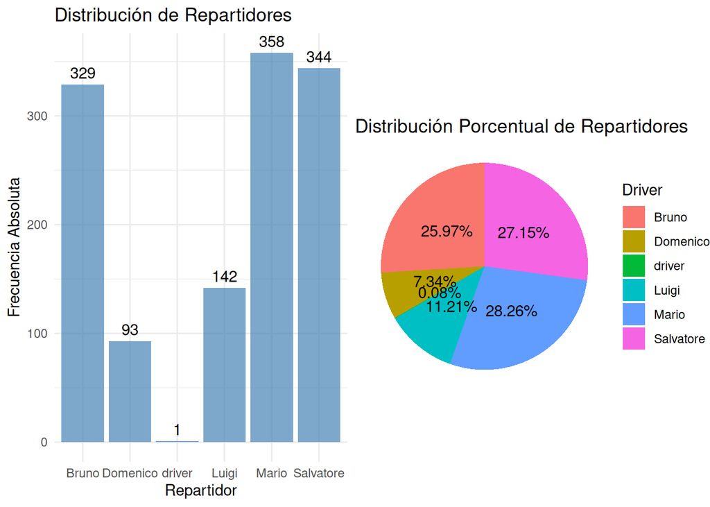

```r
# Gráfico de barras
p1 <- ggplot(datos, aes(x = driver)) +
  geom_bar(fill = "steelblue", alpha = 0.7) +
  geom_text(stat = "count", aes(label = ..count..), vjust = -0.5) +
  labs(title = "Distribución de Repartidores",
       x = "Repartidor",
       y = "Frecuencia Absoluta") +
  theme_minimal()

# Gráfico circular
pie_data <- tabla_driver
p2 <- ggplot(pie_data, aes(x = "", y = Frecuencia_Absoluta, fill = Driver)) +
  geom_bar(stat = "identity", width = 1) +
  coord_polar("y", start = 0) +
  labs(title = "Distribución Porcentual de Repartidores") +
  theme_void() +
  geom_text(aes(label = paste0(Porcentaje, "%")),
            position = position_stack(vjust = 0.5))

grid.arrange(p1, p2, ncol = 2)
```

**Conclusión Problema 2:** La distribución de entregas por repartidor muestra que Mario realizó el mayor número de entregas (358 entregas, 28.3%), mientras que driver realizó el menor número (1 entregas, 0.1%). Esto sugiere una distribución desigual de la carga de trabajo entre repartidores.

# Problema 3: Histograma de Temperature

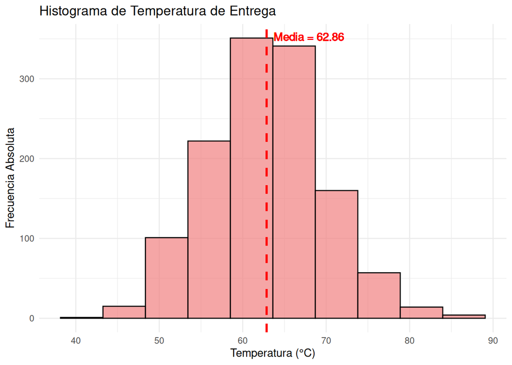

```r
# Estadísticas básicas de temperature
media_temp <- mean(datos$temperature, na.rm = TRUE)
mediana_temp <- median(datos$temperature, na.rm = TRUE)

# Histograma
hist_temp <- ggplot(datos, aes(x = temperature)) +
  geom_histogram(bins = 10, fill = "lightcoral", alpha = 0.7, color = "black") +
  geom_vline(xintercept = media_temp, color = "red", linetype = "dashed", size = 1) +
  geom_text(aes(x = media_temp, y = Inf, label = paste("Media =", round(media_temp, 2))),
            vjust = 2, hjust = -0.1, color = "red") +
  labs(title = "Histograma de Temperatura de Entrega",
       x = "Temperatura (°C)",
       y = "Frecuencia Absoluta") +
  theme_minimal()

print(hist_temp)
```

```r
# Determinar el intervalo donde se encuentra la media
hist_data <- hist(datos$temperature, plot = FALSE, breaks = 10)
intervalos <- data.frame(
  Intervalo = paste0("[", round(hist_data$breaks[-length(hist_data$breaks)], 1),
                     ", ", round(hist_data$breaks[-1], 1), ")"),
  Frecuencia = hist_data$counts
)

# Encontrar en qué intervalo está la media
intervalo_media <- which(media_temp >= hist_data$breaks[-length(hist_data$breaks)] &
                        media_temp < hist_data$breaks[-1])

knitr::kable(intervalos, caption = "Intervalos de Clase - Temperatura")
```

Intervalos de Clase - Temperatura

| Intervalo | Frecuencia |
| --- | --- |
| [40, 45) | 3 |
| [45, 50) | 37 |
| [50, 55) | 123 |
| [55, 60) | 278 |
| [60, 65) | 356 |
| [65, 70) | 285 |
| [70, 75) | 135 |
| [75, 80) | 37 |
| [80, 85) | 10 |
| [85, 90) | 2 |

**Conclusión Problema 3:** La media aritmética de la temperatura (62.86°C) se encuentra en el intervalo [60, 65), que corresponde al intervalo con mayor frecuencia en el histograma. Esto indica una distribución relativamente simétrica de las temperaturas de entrega.

# Problema 4: Análisis Descriptivo de “time”

```r
# Estadísticas descriptivas completas
media_time <- mean(datos$time, na.rm = TRUE)
mediana_time <- median(datos$time, na.rm = TRUE)
desv_time <- sd(datos$time, na.rm = TRUE)
coef_var <- (desv_time / media_time) * 100

# Estadísticas adicionales
stats_time <- data.frame(
  Estadística = c("Media", "Mediana", "Desviación Estándar", "Coeficiente de Variación (%)",
                  "Mínimo", "Máximo", "Primer Cuartil", "Tercer Cuartil", "Rango"),
  Valor = c(round(media_time, 2), round(mediana_time, 2), round(desv_time, 2),
            round(coef_var, 2), min(datos$time, na.rm = TRUE),
            max(datos$time, na.rm = TRUE),
            round(quantile(datos$time, 0.25, na.rm = TRUE), 2),
            round(quantile(datos$time, 0.75, na.rm = TRUE), 2),
            max(datos$time, na.rm = TRUE) - min(datos$time, na.rm = TRUE))
)

knitr::kable(stats_time, caption = "Estadísticas Descriptivas - Tiempo de Entrega")
```

Estadísticas Descriptivas - Tiempo de Entrega

| Estadística | Valor |
| --- | --- |
| Media | 34.23 |
| Mediana | 34.40 |
| Desviación Estándar | 6.46 |
| Coeficiente de Variación (%) | 18.88 |
| Mínimo | 12.30 |
| Máximo | 53.10 |
| Primer Cuartil | 30.10 |
| Tercer Cuartil | 38.60 |
| Rango | 40.80 |

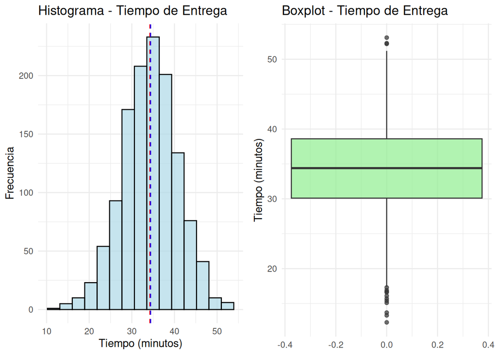

```r
# Histograma y boxplot
p1_time <- ggplot(datos, aes(x = time)) +
  geom_histogram(bins = 15, fill = "lightblue", alpha = 0.7, color = "black") +
  geom_vline(xintercept = media_time, color = "red", linetype = "dashed") +
  geom_vline(xintercept = mediana_time, color = "blue", linetype = "dashed") +
  labs(title = "Histograma - Tiempo de Entrega",
       x = "Tiempo (minutos)",
       y = "Frecuencia") +
  theme_minimal()

p2_time <- ggplot(datos, aes(y = time)) +
  geom_boxplot(fill = "lightgreen", alpha = 0.7) +
  labs(title = "Boxplot - Tiempo de Entrega",
       y = "Tiempo (minutos)") +
  theme_minimal()

grid.arrange(p1_time, p2_time, ncol = 2)
```

**Conclusión Problema 4:** El tiempo promedio de entrega es 34.23 minutos con una mediana de 34.4 minutos. El coeficiente de variación del 18.88% indica una variabilidad moderada. La diferencia entre media y mediana sugiere una ligera asimetría en la distribución de los tiempos de entrega.

# Problema 5: Análisis de Desempeño por Repartidor

```r
# Análisis por repartidor
analisis_driver <- datos %>%
  group_by(driver) %>%
  summarise(
    Entregas = n(),
    Tiempo_Promedio = round(mean(time, na.rm = TRUE), 2),
    Tiempo_Mediana = round(median(time, na.rm = TRUE), 2),
    Desv_Estandar = round(sd(time, na.rm = TRUE), 2),
    Coef_Variacion = round((sd(time, na.rm = TRUE) / mean(time, na.rm = TRUE)) * 100, 2),
    Tiempo_Min = min(time, na.rm = TRUE),
    Tiempo_Max = max(time, na.rm = TRUE)
  ) %>%
  arrange(Tiempo_Promedio)

knitr::kable(analisis_driver, caption = "Análisis de Desempeño por Repartidor")
```

Análisis de Desempeño por Repartidor

| driver | Entregas | Tiempo_Promedio | Tiempo_Mediana | Desv_Estandar | Coef_Variacion | Tiempo_Min | Tiempo_Max |
| --- | --- | --- | --- | --- | --- | --- | --- |
| Domenico | 93 | 29.32 | 29.00 | 6.50 | 22.17 | 15.1 | 47.3 |
| Luigi | 142 | 33.38 | 32.85 | 5.74 | 17.18 | 22.5 | 51.2 |
| Mario | 358 | 34.46 | 34.45 | 6.37 | 18.48 | 16.6 | 52.2 |
| Salvatore | 344 | 34.63 | 34.70 | 6.04 | 17.44 | 16.9 | 48.7 |
| Bruno | 329 | 35.31 | 35.80 | 6.65 | 18.83 | 12.3 | 53.1 |
| driver | 1 | NaN | NA | NA | NA | Inf | -Inf |

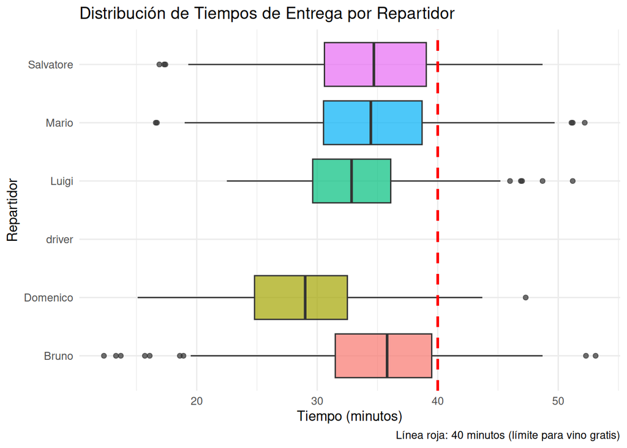

```r
# Boxplot comparativo
boxplot_drivers <- ggplot(datos, aes(x = driver, y = time, fill = driver)) +
  geom_boxplot(alpha = 0.7) +
  geom_hline(yintercept = 40, color = "red", linetype = "dashed", size = 1) +
  labs(title = "Distribución de Tiempos de Entrega por Repartidor",
       x = "Repartidor",
       y = "Tiempo (minutos)",
       caption = "Línea roja: 40 minutos (límite para vino gratis)") +
  theme_minimal() +
  theme(legend.position = "none") +
  coord_flip()

print(boxplot_drivers)
```

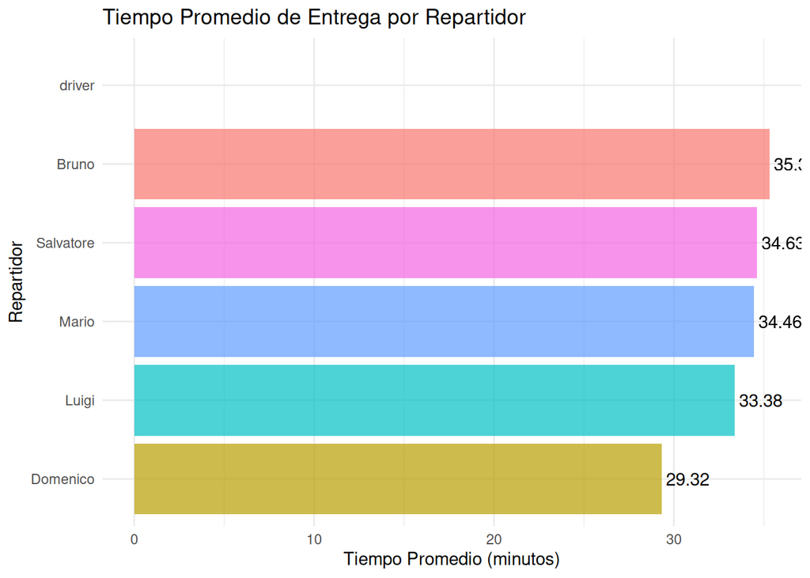

```r
# Gráfico de barras para tiempo promedio
bar_promedio <- ggplot(analisis_driver, aes(x = reorder(driver, Tiempo_Promedio),
                                           y = Tiempo_Promedio, fill = driver)) +
  geom_bar(stat = "identity", alpha = 0.7) +
  geom_text(aes(label = Tiempo_Promedio), hjust = -0.1) +
  labs(title = "Tiempo Promedio de Entrega por Repartidor",
       x = "Repartidor",
       y = "Tiempo Promedio (minutos)") +
  theme_minimal() +
  theme(legend.position = "none") +
  coord_flip()

print(bar_promedio)
```

```r
# Análisis de entregas tardías (>40 min)
entregas_tardias <- datos %>%
  group_by(driver) %>%
  summarise(
    Total_Entregas = n(),
    Entregas_Tardias = sum(time > 40, na.rm = TRUE),
    Porcentaje_Tardias = round((Entregas_Tardias / Total_Entregas) * 100, 2)
  ) %>%
  arrange(Porcentaje_Tardias)

knitr::kable(entregas_tardias, caption = "Análisis de Entregas Tardías por Repartidor")
```

Análisis de Entregas Tardías por Repartidor

| driver | Total_Entregas | Entregas_Tardias | Porcentaje_Tardias |
| --- | --- | --- | --- |
| driver | 1 | 0 | 0.00 |
| Domenico | 93 | 6 | 6.45 |
| Luigi | 142 | 17 | 11.97 |
| Mario | 358 | 61 | 17.04 |
| Salvatore | 344 | 68 | 19.77 |
| Bruno | 329 | 76 | 23.10 |

**Conclusión Problema 5:** Basándose únicamente en el tiempo de entrega, **Domenico** tuvo el mejor desempeño durante mayo con:

- Tiempo promedio más bajo: 29.32 minutos
- Menor porcentaje de entregas tardías: 6.45%
- Coeficiente de variación: 22.17%

# Resumen General

Este análisis descriptivo revela patrones importantes en el servicio de entrega:

1. **Variables**: Correctamente clasificadas entre categóricas y cuantitativas
2. **Repartidores**: Distribución desigual de entregas entre el equipo
3. **Temperatura**: Distribución simétrica alrededor de 62.86°C
4. **Tiempos**: Promedio de 34.23 minutos con variabilidad moderada
5. **Desempeño**: Domenico es el repartidor más eficiente

Estas conclusiones pueden guiar decisiones operativas para mejorar el servicio de entrega.